# Going up

So far I’ve just been looking at daughters / grand-daughters. Need to look at mothers and grandmothers. The set-up is a bit different to the progeny, but is still a weighted average of survivals and fertility at different ages. When looking at daughters, we knew the age of the mother (ego) but not the daughter. When looking at mothers, we know the age of the daughter (ego) but not the mother. This actually makes making things time-varying (with respect to fertility, anyway) much easier: the maternity schedule is now a period schedule, at time $t-a$. “Easier” assuming we have the required data.

The formula for mothers is

$$M_1(a) = \int_{\alpha}^{\beta} \frac{l_{x+a}}{l_x} W(x|t-a)dx$$

Here, $W(x|t-a)$ is the age distribution of women who gave birth to a daughter at time $t-a$. There’s a nice recurrence relation here; the grandmothers equation is

$$M_2(a) = \int_{\alpha}^{\beta} M_1(a+x) W(x|t-a)dx$$

The stable population version of mothers is

$$\int_{\alpha}^{\beta} l_{x+a}m_x e^{-rx}dx$$

Where $r$ is the intrinsic rate of increase. Similar to before, the discrete version is

$$\sum_{\alpha = 15}^{45} {_5L_{a+x}}\cdot {_5F_x}\cdot e^{-r(x+5/2)}$$

Let’s start with calculating the stable version. Load in the data

```r
library(tidyverse)
library(here)
source(here("code", "kin_functions.R"))
lt <- read_csv(here("data", "wpp_lt.csv"))
fx <- read_csv(here("data", "wpp_fx.csv"))
```

Tidy up and join the two datasets:

```r
# mortality df
df_mort <- lt %>%
  # tidy up names
  rename(year = Period,
         region = `Region, subregion, country or area *`,
         age = `Age (x)`,
         Lx = `Number of person-years lived L(x,n)`) %>%
  # just keep the columns we need
  select(year, region, age, Lx)
# fertility df
df_fert <- fx %>%
  # tidy up names
  rename(year = Period,
         region = `Region, subregion, country or area *`) %>%
  # only keep years/ages/countries we want
  select(year, region, `15-19`:`45-49`) %>%
  # change to long format
  gather(age_group, Fx, -year, -region) %>%
  # make an age column
  mutate(age = as.numeric(substring(age_group, 1, 2)))
# join the two bits, and fill in the missing info (fertility only goes to age 49)
df <- df_mort %>%
  left_join(df_fert) %>%
  mutate(age_group = paste(age, age+4, sep = "-"),
         Fx = ifelse(is.na(Fx), 0, Fx)) %>%
  rename(period = year) %>%
  mutate(year = as.numeric(substring(period, 1,4)))
```

For the stable calculations, we need to calculate NRR and then $r$. I’m assuming mean age at childbearing is 25 everywhere. Probably not great but oh well.

```r
repro_measures <- df %>%
  group_by(region, year) %>%
  summarise(nrr = sum(Fx/10^3*Lx/10^5*0.4886),
            intr_r = log(nrr)/25)
```

Let’s plot some of these to get a feel for them

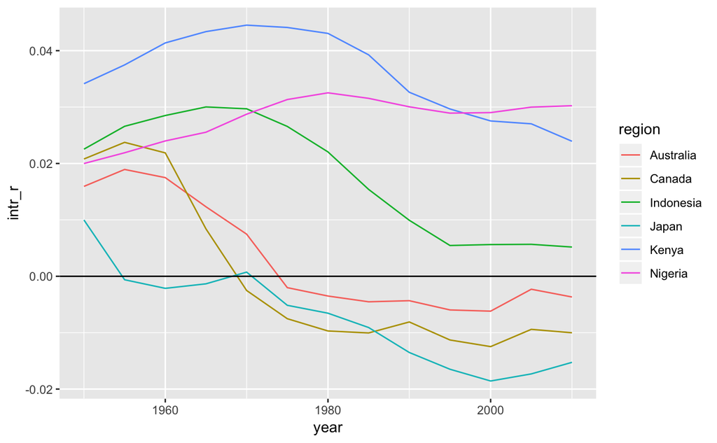

```r
repro_measures %>%
  filter(region %in% c("Nigeria", "Australia", "Kenya", "Indonesia", "Canada", "Japan")) %>%
  ggplot(aes(year, intr_r, color = region)) + geom_line() +geom_hline(yintercept = 0)
```

Right, let’s give it a go (function to calculate number of mothers and grandmother is in the `kin_functions` file).

```r
this_year <- 2010
age_a <- 35
country <- "Australia"
this_d <- df %>% filter(region == country, year == this_year)
this_r <- repro_measures %>% ungroup() %>% filter(region==country, year == this_year) %>% select(intr_r) %>% pull()
surviving_mothers_stable(this_d, age_a, this_r)
```

```
[1] 0.9414587
```

```r
surviving_grandmothers_stable(this_d, age_a, this_r)
```

```
[1] 0.2631247
```

Seems to work, let’s do it for a few years / countries.

```r
countries <- c("United States of America", "Japan", "Nigeria", "Venezuela (Bolivarian Republic of)")
years <- c(1955, 1975, 1995, 2005)
df_data <- df %>%
  filter(region %in% countries, year %in% years)
df_res <- c()
for(i in 1:length(countries)){
  df_country <- c()
  for(j in 1:length(years)){
    this_df_data <- df_data %>%
      filter(region == countries[i],
             year == years[j])
    this_r <- repro_measures %>% ungroup() %>% filter(region==countries[i], year == years[j]) %>% select(intr_r) %>% pull()
    df_direct <- tibble(mother_age = seq(15, 85, by = 5),
                        country = countries[i],
                        year = years[j])
    df_direct <- df_direct %>%
      rowwise() %>%
      mutate(mothers = surviving_mothers_stable(this_df_data, mother_age, this_r),
             grandmothers = surviving_grandmothers_stable(this_df_data, mother_age, this_r))

    df_country <- rbind(df_country, df_direct)
  }
  df_res <- rbind(df_res, df_country)
}
```

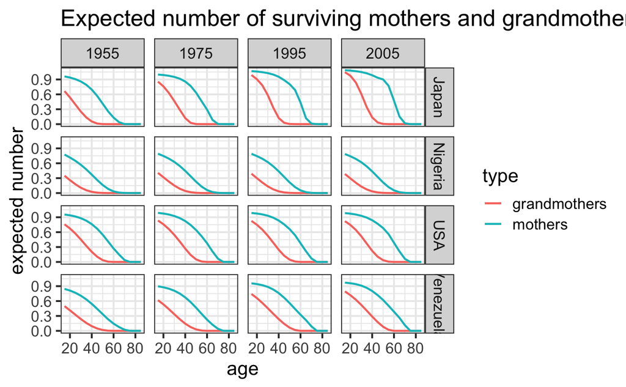

```r
df_res %>%
  mutate(country_label = case_when(
    country=="Venezuela (Bolivarian Republic of)" ~ "Venezuela",
    country=="United States of America" ~ "USA",
    TRUE ~ country
  )) %>%
  gather(type, number, -mother_age, -country, -year, -country_label) %>%
  ggplot(aes(mother_age, number, color = type)) + geom_line(lwd = 0.8) +
  facet_grid(country_label~year) +
  ylab("expected number") + xlab("age") +
  ggtitle("Expected number of surviving mothers and grandmothers") +
  theme_bw(base_size = 16)
ggsave(here("fig", "country_year_mother_gmother.pdf"), width = 12, height = 10)
```